# BMIS-2542: Data Programming Essentials *with Python*

## Assignment-3

- Name : Sree Ram Avinash Maddikonda
- Email : srm153@pitt.edu

Data Source:  
Data downloaded programmatically from the World Bank using the API as per below documentation:-  
https://wbdata.readthedocs.io/en/stable/

Narrative

- Due to urbanization, the air pollution is increasing – for this have chosen 12 countries over an 8-year period and explanation is backed by the World Bank’s “Environment, Social and Governance (ESG) Data”. (Indicator #75)
- We are leveraging Data Vignette such as graphs, because we get to see the trends of PM2.5 – how much and the rate of rise in pollution levels YoY. If it’s a national channel, it would be broadcasted to wider audience.

Hypothesis with explanation

Hypothesis:- I would like to establish that increasing urbanization is causing air pollution to increase over an 8/10-year period.  
Air Pollution levels are rising mainly due to

Increased construction activity -

- big commercial establishments like IT Parks/SEZs even near residential areas
- construction of high-rise apartments, most of which are unoccupied - more than what’s necessary at the moment especially in Metropolitan and Cosmopolitan cities (Supply > Demand)

Increased vehicular emissions (especially Developing Countries)

- roads aren’t optimized for traffic flow and vehicles getting stuck in traffic jams for hours.
- In addition, Diesel vehicles (>2000cc) should not be allowed to ply if score on the pollution certificate is less than the threshold value.

Here begins the coding part for doing the analysis on the dataset

```python
import pandas as pd
import matplotlib.pyplot as plt
%matplotlib inline
import seaborn as sns
```

```python
pip install -U wbdata
```

```python
import wbdata
import datetime
```

First, checking for the appropriate dataset based on the Indicators available using the WB API

```python
wbdata.get_source()
```

```
  id  name
----  --------------------------------------------------------------------
   1  Doing Business
   2  World Development Indicators
   3  Worldwide Governance Indicators
   5  Subnational Malnutrition Database
   6  International Debt Statistics
  11  Africa Development Indicators
  12  Education Statistics
  13  Enterprise Surveys
  14  Gender Statistics
  15  Global Economic Monitor
  16  Health Nutrition and Population Statistics
  18  IDA Results Measurement System
  19  Millennium Development Goals
```

[output cut: 53 more lines]

Next, the Indicator #75 is the appropriate one, so lets choose that

```python
wbdata.get_indicator(source=75)
```

```
id                 name
-----------------  ---------------------------------------------------------------------------------------------------------
AG.LND.AGRI.ZS     Agricultural land (% of land area)
AG.LND.FRST.ZS     Forest area (% of land area)
AG.PRD.FOOD.XD     Food production index (2014-2016 = 100)
CC.EST             Control of Corruption: Estimate
EG.CFT.ACCS.ZS     Access to clean fuels and technologies for cooking (% of population)
EG.EGY.PRIM.PP.KD  Energy intensity level of primary energy (MJ/$2011 PPP GDP)
EG.ELC.ACCS.ZS     Access to electricity (% of population)
EG.ELC.COAL.ZS     Electricity production from coal sources (% of total)
EG.ELC.RNEW.ZS     Renewable electricity output (% of total electricity output)
EG.FEC.RNEW.ZS     Renewable energy consumption (% of total final energy consumption)
EG.IMP.CONS.ZS     Energy imports, net (% of energy use)
EG.USE.COMM.FO.ZS  Fossil fuel energy consumption (% of total)
EG.USE.PCAP.KG.OE  Energy use (kg of oil equivalent per capita)
EN.ATM.CO2E.PC     CO2 emissions (metric tons per capita)
EN.ATM.METH.PC     Methane emissions (kt of CO2 equivalent per capita)
EN.ATM.NOXE.PC     Nitrous oxide emissions (metric tons of CO2 equivalent per capita)
EN.ATM.PM25.MC.M3  PM2.5 air pollution, mean annual exposure (micrograms per cubic meter)
EN.CLC.CDDY.XD     Cooling Degree Days (projected change in number of degree Celsius)
EN.CLC.GHGR.MT.CE  GHG net emissions/removals by LUCF (Mt of CO2 equivalent)
EN.CLC.HEAT.XD     Heat Index 35 (projected change in days)
EN.CLC.MDAT.ZS     Droughts, floods, extreme temperatures (% of population, average 1990-2009)
EN.CLC.PRCP.XD     Maximum 5-day Rainfall, 25-year Return Level (projected change in mm)
EN.CLC.SPEI.XD     Mean Drought Index (projected change, unitless)
EN.MAM.THRD.NO     Mammal species, threatened
EN.POP.DNST        Population density (people per sq. km of land area)
ER.H2O.FWTL.ZS     Annual freshwater withdrawals, total (% of internal resources)
ER.PTD.TOTL.ZS     Terrestrial and marine protected areas (% of total territorial area)
GB.XPD.RSDV.GD.ZS  Research and development expenditure (% of GDP)
GE.EST             Government Effectiveness: Estimate
IC.BUS.EASE.XQ     Ease of doing business index (1=most business-friendly regulations)
IC.LGL.CRED.XQ     Strength of legal rights index (0=weak to 12=strong)
IP.JRN.ARTC.SC     Scientific and technical journal articles
IP.PAT.RESD        Patent applications, residents
IT.NET.USER.ZS     Individuals using the Internet (% of population)
NV.AGR.TOTL.ZS     Agriculture, forestry, and fishing, value added (% of GDP)
NY.ADJ.DFOR.GN.ZS  Adjusted savings: net forest depletion (% of GNI)
NY.ADJ.DRES.GN.ZS  Adjusted savings: natural resources depletion (% of GNI)
NY.GDP.MKTP.KD.ZG  GDP growth (annual %)
```

[output cut: 14 more lines]

```
SI.DST.FRST.20     Income share held by lowest 20%
SI.POV.GINI        Gini index (World Bank estimate)
SI.POV.NAHC        Poverty headcount ratio at national poverty lines (% of population)
SI.SPR.PCAP.ZG     Annualized average growth rate in per capita real survey mean consumption or income, total population (%)
SL.TLF.0714.ZS     Children in employment, total (% of children ages 7-14)
SL.TLF.ACTI.ZS     Labor force participation rate, total (% of total population ages 15-64) (modeled ILO estimate)
SL.TLF.CACT.FM.ZS  Ratio of female to male labor force participation rate (%) (modeled ILO estimate)
SL.UEM.TOTL.ZS     Unemployment, total (% of total labor force) (modeled ILO estimate)
SM.POP.NETM        Net migration
SN.ITK.DEFC.ZS     Prevalence of undernourishment (% of population)
SP.DYN.LE00.IN     Life expectancy at birth, total (years)
SP.DYN.TFRT.IN     Fertility rate, total (births per woman)
SP.POP.65UP.TO.ZS  Population ages 65 and above (% of total population)
SP.UWT.TFRT        Unmet need for contraception (% of married women ages 15-49)
VA.EST             Voice and Accountability: Estimate
```

The most appropriate indicator for our narrative is:-

- EN.ATM.PM25.MC.M3 PM2.5 air pollution, mean annual exposure (micrograms per cubic meter)

So selecting that for the analysis

Next, setting the date range as 2010 to 2020 for seeing the PM2.5 levels trend over a 10-year time period

```python
data_date = datetime.datetime(2010, 1, 1), datetime.datetime(2020, 12, 31)
```

Next, to get the country code, executing the below commands:-

```python
#'India'
#'Germany'
#'Switzerland'
#'Brazil'
#'Singapore'
#'Malaysia'
#'South Africa'
#'Australia'
#'Canada'
print(wbdata.search_countries('India'))
print('\n')
print(wbdata.search_countries('Germany'))
print('\n')
print(wbdata.search_countries('Switzerland'))
print('\n')
print(wbdata.search_countries('Brazil'))
print('\n')
print(wbdata.search_countries('Singapore'))
print('\n')
print(wbdata.search_countries('Malaysia'))
print('\n')
print(wbdata.search_countries('South Africa'))
print('\n')
print(wbdata.search_countries('Australia'))
print('\n')
print(wbdata.search_countries('Canada'))
print('\n')
print(wbdata.search_countries('Greenland'))
```

```
id    name
----  ------
IND   India


id    name
----  -------
DEU   Germany


id    name
----  -----------
CHE   Switzerland


id    name
----  ------
BRA   Brazil


id    name
----  ---------
SGP   Singapore


id    name
----  --------
MYS   Malaysia


id    name
----  -----------------------------------------------------
SXZ   Sub-Saharan Africa excluding South Africa
XZN   Sub-Saharan Africa excluding South Africa and Nigeria
ZAF   South Africa


id    name
----  ---------
AUS   Australia


id    name
----  ------
CAN   Canada


id    name
----  ---------
GRL   Greenland
```

Now that we have selected

- indicator - EN.ATM.PM25.MC.M3
- country codes - "USA", "GBR","IND","DEU","CHE","BRA","SGP","MYS","ZAF","AUS","CAN","GRL"
- date range - 2010 to 2020

Let us download the dataset programatically using the API and loading it in the Pandas DataFrame as shown below:

```python
indicators = {"EN.ATM.PM25.MC.M3": "PM2.5_mean_annual_exp"}
```

```python
df_esgdata = wbdata.get_dataframe(indicators, country=["USA", "GBR","IND","DEU","CHE","BRA","SGP","MYS","ZAF","AUS","CAN","GRL"],
                data_date=data_date, convert_date=True)
```

Now, let us explore the dataset:- first, we will check the columns and also the first 15 rows

```python
print(df_esgdata.columns)
print("The number of rows are:- {}".format(df_esgdata.shape[0]))
print("The number of columns are:- {}".format(df_esgdata.shape[1]))
```

```
Index(['PM2.5_mean_annual_exp'], dtype='object')
The number of rows are:- 132
The number of columns are:- 1
```

```python
df_esgdata.head(15)
```

| country | date | PM2.5_mean_annual_exp |
| --- | --- | --- |
| Australia | 2020-01-01 | NaN |
|  | 2019-01-01 | NaN |
|  | 2018-01-01 | NaN |
|  | 2017-01-01 | 8.550324 |
|  | 2016-01-01 | 8.614509 |
|  | 2015-01-01 | 9.320015 |
|  | 2014-01-01 | 9.492979 |
|  | 2013-01-01 | 9.987684 |
|  | 2012-01-01 | 10.537090 |
|  | 2011-01-01 | 11.047265 |
|  | 2010-01-01 | 10.618879 |
| Brazil | 2020-01-01 | NaN |
|  | 2019-01-01 | NaN |
|  | 2018-01-01 | NaN |
|  | 2017-01-01 | 12.706629 |

As can be observed from the above, Data for the years 2018-2020 isn’t available in the WB ESG dataset.

Therefore, Let us consider another 10-year Date range - 2008 to 2017  
and re-executing the API call with this new Date range and loading the downloaded data to the DataFrame

```python
data_date = datetime.datetime(2008, 12, 31), datetime.datetime(2017, 12, 31)
```

```python
df_esgdata = wbdata.get_dataframe(indicators, country=["USA", "GBR","IND","DEU","CHE","BRA","SGP","MYS","ZAF","AUS","CAN"],
                data_date=data_date, convert_date=True)
```

```python
df_esgdata.head(15)
```

| country | date | PM2.5_mean_annual_exp |
| --- | --- | --- |
| Australia | 2017-01-01 | 8.550324 |
|  | 2016-01-01 | 8.614509 |
|  | 2015-01-01 | 9.320015 |
|  | 2014-01-01 | 9.492979 |
|  | 2013-01-01 | 9.987684 |
|  | 2012-01-01 | 10.537090 |
|  | 2011-01-01 | 11.047265 |
|  | 2010-01-01 | 10.618879 |
|  | 2009-01-01 | NaN |
|  | 2008-01-01 | NaN |
| Brazil | 2017-01-01 | 12.706629 |
|  | 2016-01-01 | 12.658676 |
|  | 2015-01-01 | 13.594656 |
|  | 2014-01-01 | 13.989935 |
|  | 2013-01-01 | 14.609901 |

As can be observed from the above, Data for the years 2008-2009 isn’t available in the WB ESG dataset.

Therefore, Let us finalize the Date range - 2010 to 2017  
and re-executing the API call with this new Date range and loading the downloaded data to the DataFrame

```python
data_date = datetime.datetime(2010, 12, 31), datetime.datetime(2017, 12, 31)
```

```python
df_esgdata = wbdata.get_dataframe(indicators, country=["USA", "GBR","IND","DEU","CHE","BRA","SGP","MYS","ZAF","AUS",\
                                                       "CAN","GRL"],
                data_date=data_date, convert_date=True)
```

Now, let us re-explore the dataset:- we will check the columns and also the first 16 rows

```python
print(df_esgdata.columns)
print("The number of rows are:- {}".format(df_esgdata.shape[0]))
print("The number of columns are:- {}".format(df_esgdata.shape[1]))
```

```
Index(['PM2.5_mean_annual_exp'], dtype='object')
The number of rows are:- 96
The number of columns are:- 1
```

```python
df_esgdata.head(16)
```

| country | date | PM2.5_mean_annual_exp |
| --- | --- | --- |
| Australia | 2017-01-01 | 8.550324 |
|  | 2016-01-01 | 8.614509 |
|  | 2015-01-01 | 9.320015 |
|  | 2014-01-01 | 9.492979 |
|  | 2013-01-01 | 9.987684 |
|  | 2012-01-01 | 10.537090 |
|  | 2011-01-01 | 11.047265 |
|  | 2010-01-01 | 10.618879 |
| Brazil | 2017-01-01 | 12.706629 |
|  | 2016-01-01 | 12.658676 |
|  | 2015-01-01 | 13.594656 |
|  | 2014-01-01 | 13.989935 |
|  | 2013-01-01 | 14.609901 |
|  | 2012-01-01 | 15.285456 |
|  | 2011-01-01 | 15.912798 |
|  | 2010-01-01 | 15.955285 |

Further exploring the rows by filtering the dataset corresponding to Country India

```python
i = df_esgdata.index.get_loc('India')
df_esgdata_ind = df_esgdata.iloc[i]
df_esgdata_ind
```

| country | date | PM2.5_mean_annual_exp |
| --- | --- | --- |
| India | 2017-01-01 | 90.873210 |
|  | 2016-01-01 | 89.672177 |
|  | 2015-01-01 | 89.303334 |
|  | 2014-01-01 | 89.622383 |
|  | 2013-01-01 | 91.804792 |
|  | 2012-01-01 | 88.169441 |
|  | 2011-01-01 | 97.599379 |
|  | 2010-01-01 | 95.758179 |

Now, let us do Data pre-processing:

The country and date columns are part of the index  
Therefore, to make the dataset more usable for further processing and visualization, lets extract them as separate columns by applying reset_index() and melt() methods

```python
df_esgdata_2 = df_esgdata.reset_index().melt(id_vars=["country","date"])
df_esgdata_2.head()
```

|  | country | date | variable | value |
| --- | --- | --- | --- | --- |
| 0 | Australia | 2017-01-01 | PM2.5_mean_annual_exp | 8.550324 |
| 1 | Australia | 2016-01-01 | PM2.5_mean_annual_exp | 8.614509 |
| 2 | Australia | 2015-01-01 | PM2.5_mean_annual_exp | 9.320015 |
| 3 | Australia | 2014-01-01 | PM2.5_mean_annual_exp | 9.492979 |
| 4 | Australia | 2013-01-01 | PM2.5_mean_annual_exp | 9.987684 |

Now, lets extract the Year from date:-

```python
df_esgdata_2['Year'] = df_esgdata_2['date'].dt.year
df_esgdata_2.head()
```

|  | country | date | variable | value | Year |
| --- | --- | --- | --- | --- | --- |
| 0 | Australia | 2017-01-01 | PM2.5_mean_annual_exp | 8.550324 | 2017 |
| 1 | Australia | 2016-01-01 | PM2.5_mean_annual_exp | 8.614509 | 2016 |
| 2 | Australia | 2015-01-01 | PM2.5_mean_annual_exp | 9.320015 | 2015 |
| 3 | Australia | 2014-01-01 | PM2.5_mean_annual_exp | 9.492979 | 2014 |
| 4 | Australia | 2013-01-01 | PM2.5_mean_annual_exp | 9.987684 | 2013 |

Now, another pre-processing step: lets drop the variable column as it is not useful

```python
df_esgdata_2.drop('variable', axis='columns', inplace=True)
df_esgdata_2
```

|  | country | date | value | Year |
| --- | --- | --- | --- | --- |
| 0 | Australia | 2017-01-01 | 8.550324 | 2017 |
| 1 | Australia | 2016-01-01 | 8.614509 | 2016 |
| 2 | Australia | 2015-01-01 | 9.320015 | 2015 |
| 3 | Australia | 2014-01-01 | 9.492979 | 2014 |
| 4 | Australia | 2013-01-01 | 9.987684 | 2013 |
| ... | ... | ... | ... | ... |
| 91 | South Africa | 2014-01-01 | 26.722212 | 2014 |
| 92 | South Africa | 2013-01-01 | 26.729262 | 2013 |
| 93 | South Africa | 2012-01-01 | 26.577087 | 2012 |
| 94 | South Africa | 2011-01-01 | 26.557873 | 2011 |
| 95 | South Africa | 2010-01-01 | 27.138587 | 2010 |

96 rows × 4 columns

Now, another pre-processing step: lets rename the value column as PM2.5_mean_annual_exp

```python
df_esgdata_2.rename(columns={'value': 'PM2.5_mean_annual_exp'}, inplace=True)
df_esgdata_2
```

|  | country | date | PM2.5_mean_annual_exp | Year |
| --- | --- | --- | --- | --- |
| 0 | Australia | 2017-01-01 | 8.550324 | 2017 |
| 1 | Australia | 2016-01-01 | 8.614509 | 2016 |
| 2 | Australia | 2015-01-01 | 9.320015 | 2015 |
| 3 | Australia | 2014-01-01 | 9.492979 | 2014 |
| 4 | Australia | 2013-01-01 | 9.987684 | 2013 |
| ... | ... | ... | ... | ... |
| 91 | South Africa | 2014-01-01 | 26.722212 | 2014 |
| 92 | South Africa | 2013-01-01 | 26.729262 | 2013 |
| 93 | South Africa | 2012-01-01 | 26.577087 | 2012 |
| 94 | South Africa | 2011-01-01 | 26.557873 | 2011 |
| 95 | South Africa | 2010-01-01 | 27.138587 | 2010 |

96 rows × 4 columns

Now, after the above pre-processing steps, Lets check the rows by filtering the dataset corresponding to Country India

```python
df_esgdata_ind_2 = df_esgdata_2.query("country=='India'")
df_esgdata_ind_2
```

|  | country | date | PM2.5_mean_annual_exp | Year |
| --- | --- | --- | --- | --- |
| 56 | India | 2017-01-01 | 90.873210 | 2017 |
| 57 | India | 2016-01-01 | 89.672177 | 2016 |
| 58 | India | 2015-01-01 | 89.303334 | 2015 |
| 59 | India | 2014-01-01 | 89.622383 | 2014 |
| 60 | India | 2013-01-01 | 91.804792 | 2013 |
| 61 | India | 2012-01-01 | 88.169441 | 2012 |
| 62 | India | 2011-01-01 | 97.599379 | 2011 |
| 63 | India | 2010-01-01 | 95.758179 | 2010 |

We are setting the below global params so that they apply to all the graphs

```python
plt.rc('font', family = 'sans-serif')
plt.rc('xtick', labelsize = 14)
plt.rc('ytick', labelsize = 14)
plt.rc('font', size = 14)
```

Hypothesis in the form of model specifications

- Well-known Measure for estimating the air pollution levels: Particulate Matter i.e., PM 2.5
- Dependent Variable (on y-axis): PM2.5 air pollution, mean annual exposure (micrograms per cubic meter)
- Independent Variable (on x-axis): 8-year time period i.e., years from 2010-2017
- Please note: Data for the years 2008-2009 and 2018-2020 isn’t available on the website.
- Countries selected for analysis: 'India', 'United States', 'United Kingdom', 'Australia', 'Canada', 'Singapore', 'Malaysia', 'South Africa', 'Brazil', 'Switzerland', 'Germany’, 'Greenland'
- Hypothesis formula: PM2.5 air pollution = f(Country, 8-year time period)

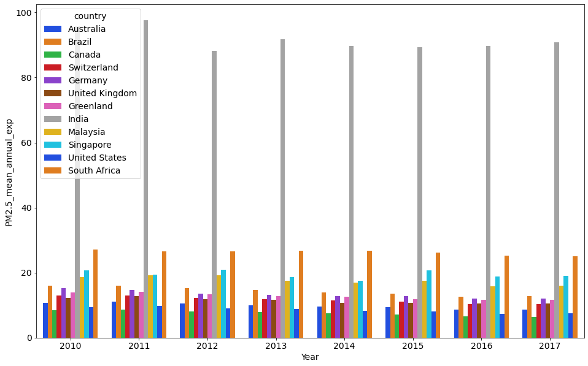

```python
plot_height = 10
plot_width = 16
fig, axs = plt.subplots(1, 1,figsize=(plot_width,plot_height))
sns.barplot(x="Year", y="PM2.5_mean_annual_exp", hue="country", data=df_esgdata_2,palette="bright")
```

Observations:

- Country having the highest PM2.5 levels is India over the 8-year period (Gray color bar)
- Country having the lowest PM2.5 levels is Canada over the 8-year period (Green color bar)

Now, lets drill down further to see the trends of air pollution country-wise -  
to check whether the trend line is decreasing or increasing over the 8-year period

Therefore, i am filtering the dataframe country-wise and storing the results in separate DataFrames.  
Before that Lets quickly check the country names

```python
df_esgdata_2.country.unique()
```

```
array(['Australia', 'Brazil', 'Canada', 'Switzerland', 'Germany',
       'United Kingdom', 'Greenland', 'India', 'Malaysia', 'Singapore',
       'United States', 'South Africa'], dtype=object)
```

```python
df_esgdata_ind_2 = df_esgdata_2.query("country=='India'")
df_esgdata_USA_2 = df_esgdata_2.query("country=='United States'")
df_esgdata_UK_2 = df_esgdata_2.query("country=='United Kingdom'")
df_esgdata_ger_2 = df_esgdata_2.query("country=='Germany'")
df_esgdata_swiss_2 = df_esgdata_2.query("country=='Switzerland'")
df_esgdata_br_2 = df_esgdata_2.query("country=='Brazil'")
df_esgdata_sing_2 = df_esgdata_2.query("country=='Singapore'")
df_esgdata_malay_2 = df_esgdata_2.query("country=='Malaysia'")
df_esgdata_sa_2 = df_esgdata_2.query("country=='South Africa'")
df_esgdata_aus_2 = df_esgdata_2.query("country=='Australia'")
df_esgdata_can_2 = df_esgdata_2.query("country=='Canada'")
df_esgdata_grn_2 = df_esgdata_2.query("country=='Greenland'")
df_esgdata_arg_2 = df_esgdata_2.query("country=='Argentina'")
df_esgdata_jap_2 = df_esgdata_2.query("country=='Japan'")
```

```python
plt.rc('xtick', labelsize = 26)
plt.rc('ytick', labelsize = 26)
plt.rc('font', size = 26)
```

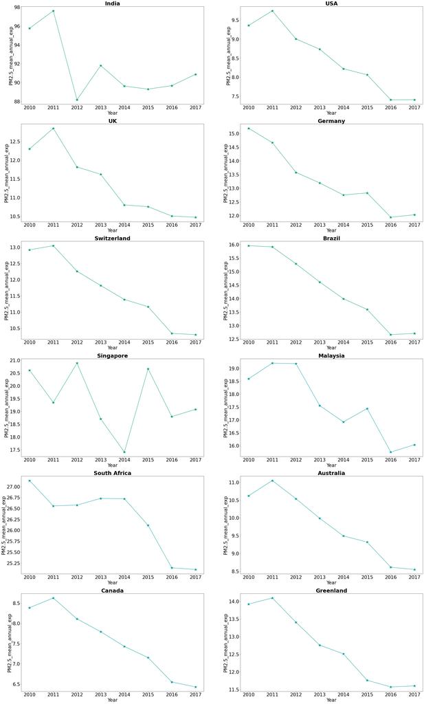

```python
plot_height = 70
plot_width = 40
fig, axs = plt.subplots(6, 2,figsize=(plot_width,plot_height))
#list(enumerate(axs))
#axs = axs.flatten()
sns.lineplot(x="Year", y="PM2.5_mean_annual_exp", ax=axs[0,0], data=df_esgdata_ind_2, color="#009973",marker="*",markersize=20).set_title("India",fontsize=30,fontweight='bold')
sns.lineplot(x="Year", y="PM2.5_mean_annual_exp", ax=axs[0,1], data=df_esgdata_USA_2, color="#009973",marker="*",markersize=20).set_title("USA",fontsize=30,fontweight='bold')
sns.lineplot(x="Year", y="PM2.5_mean_annual_exp", ax=axs[1,0], data=df_esgdata_UK_2, color="#009973",marker="*",markersize=20).set_title("UK",fontsize=30,fontweight='bold')
sns.lineplot(x="Year", y="PM2.5_mean_annual_exp", ax=axs[1,1], data=df_esgdata_ger_2, color="#009973",marker="*",markersize=20).set_title("Germany",fontsize=30,fontweight='bold')
sns.lineplot(x="Year", y="PM2.5_mean_annual_exp", ax=axs[2,0], data=df_esgdata_swiss_2, color="#009973",marker="*",markersize=20).set_title("Switzerland",fontsize=30,fontweight='bold')
sns.lineplot(x="Year", y="PM2.5_mean_annual_exp", ax=axs[2,1], data=df_esgdata_br_2, color="#009973",marker="*",markersize=20).set_title("Brazil",fontsize=30,fontweight='bold')
sns.lineplot(x="Year", y="PM2.5_mean_annual_exp", ax=axs[3,0], data=df_esgdata_sing_2, color="#009973",marker="*",markersize=20).set_title("Singapore",fontsize=30,fontweight='bold')
sns.lineplot(x="Year", y="PM2.5_mean_annual_exp", ax=axs[3,1], data=df_esgdata_malay_2, color="#009999",marker="*",markersize=20).set_title("Malaysia",fontsize=30,fontweight='bold')
sns.lineplot(x="Year", y="PM2.5_mean_annual_exp", ax=axs[4,0], data=df_esgdata_sa_2, color="#009999",marker="*",markersize=20).set_title("South Africa",fontsize=30,fontweight='bold')
sns.lineplot(x="Year", y="PM2.5_mean_annual_exp", ax=axs[4,1], data=df_esgdata_aus_2, color="#009999",marker="*",markersize=20).set_title("Australia",fontsize=30,fontweight='bold')
sns.lineplot(x="Year", y="PM2.5_mean_annual_exp", ax=axs[5,0], data=df_esgdata_can_2, color="#009999",marker="*",markersize=20).set_title("Canada",fontsize=30,fontweight='bold')
sns.lineplot(x="Year", y="PM2.5_mean_annual_exp", ax=axs[5,1], data=df_esgdata_grn_2, color="#009999",marker="*",markersize=20).set_title("Greenland",fontsize=30,fontweight='bold')
```

Observations / brief summary:-

```python
print("India")
row = df_esgdata_ind_2[df_esgdata_ind_2["PM2.5_mean_annual_exp"] == df_esgdata_ind_2["PM2.5_mean_annual_exp"].max()]
row_1 = df_esgdata_ind_2[df_esgdata_ind_2["PM2.5_mean_annual_exp"] == df_esgdata_ind_2["PM2.5_mean_annual_exp"].min()]
print("Peak PM2.5 level : {0:.2f} in Year {1}".format(row["PM2.5_mean_annual_exp"].values[0],row["Year"].values[0]))
print("lowest PM2.5 level : {0:.2f} in Year {1}".format(row_1["PM2.5_mean_annual_exp"].values[0],row_1["Year"].values[0]))
print("Average PM2.5 over the 8-year period: {:.2f}".format(df_esgdata_ind_2["PM2.5_mean_annual_exp"].mean()))
print("\n")

print("USA")
row2 = df_esgdata_USA_2[df_esgdata_USA_2["PM2.5_mean_annual_exp"] == df_esgdata_USA_2["PM2.5_mean_annual_exp"].max()]
print("Peak PM2.5 level : {0:.2f} in Year {1}".format(row2["PM2.5_mean_annual_exp"].values[0],row2["Year"].values[0]))
row2_1 = df_esgdata_USA_2[df_esgdata_USA_2["PM2.5_mean_annual_exp"] == df_esgdata_USA_2["PM2.5_mean_annual_exp"].min()]
print("lowest PM2.5 level : {0:.2f} in Year {1}".format(row2_1["PM2.5_mean_annual_exp"].values[0],row2_1["Year"].values[0]))
print("Average PM2.5 over the 8-year period: {:.2f}".format(df_esgdata_USA_2["PM2.5_mean_annual_exp"].mean()))
print("\n")

print("UK")
row3 = df_esgdata_UK_2[df_esgdata_UK_2["PM2.5_mean_annual_exp"] == df_esgdata_UK_2["PM2.5_mean_annual_exp"].max()]
print("Peak PM2.5 level : {0:.2f} in Year {1}".format(row3["PM2.5_mean_annual_exp"].values[0],row3["Year"].values[0]))
row3_1 = df_esgdata_UK_2[df_esgdata_UK_2["PM2.5_mean_annual_exp"] == df_esgdata_UK_2["PM2.5_mean_annual_exp"].min()]
print("lowest PM2.5 level : {0:.2f} in Year {1}".format(row3_1["PM2.5_mean_annual_exp"].values[0],row3_1["Year"].values[0]))
print("Average PM2.5 over the 8-year period: {:.2f}".format(df_esgdata_UK_2["PM2.5_mean_annual_exp"].mean()))
print("\n")

print("Germany")
row4 = df_esgdata_ger_2[df_esgdata_ger_2["PM2.5_mean_annual_exp"] == df_esgdata_ger_2["PM2.5_mean_annual_exp"].max()]
print("Peak PM2.5 level : {0:.2f} in Year {1}".format(row4["PM2.5_mean_annual_exp"].values[0],row4["Year"].values[0]))
row4_1 = df_esgdata_ger_2[df_esgdata_ger_2["PM2.5_mean_annual_exp"] == df_esgdata_ger_2["PM2.5_mean_annual_exp"].min()]
print("lowest PM2.5 level : {0:.2f} in Year {1}".format(row4_1["PM2.5_mean_annual_exp"].values[0],row4_1["Year"].values[0]))
print("Average PM2.5 over the 8-year period: {:.2f}".format(df_esgdata_ger_2["PM2.5_mean_annual_exp"].mean()))
print("\n")

print("Switzerland")
row5 = df_esgdata_swiss_2[df_esgdata_swiss_2["PM2.5_mean_annual_exp"] == df_esgdata_swiss_2["PM2.5_mean_annual_exp"].max()]
print("Peak PM2.5 level : {0:.2f} in Year {1}".format(row5["PM2.5_mean_annual_exp"].values[0],row5["Year"].values[0]))
row5_1 = df_esgdata_swiss_2[df_esgdata_swiss_2["PM2.5_mean_annual_exp"] == df_esgdata_swiss_2["PM2.5_mean_annual_exp"].min()]
print("lowest PM2.5 level : {0:.2f} in Year {1}".format(row5_1["PM2.5_mean_annual_exp"].values[0],row5_1["Year"].values[0]))
print("Average PM2.5 over the 8-year period: {:.2f}".format(df_esgdata_swiss_2["PM2.5_mean_annual_exp"].mean()))
print("\n")

print("Brazil")
row6 = df_esgdata_br_2[df_esgdata_br_2["PM2.5_mean_annual_exp"] == df_esgdata_br_2["PM2.5_mean_annual_exp"].max()]
print("Peak PM2.5 level : {0:.2f} in Year {1}".format(row6["PM2.5_mean_annual_exp"].values[0],row6["Year"].values[0]))
row6_1 = df_esgdata_br_2[df_esgdata_br_2["PM2.5_mean_annual_exp"] == df_esgdata_br_2["PM2.5_mean_annual_exp"].min()]
print("lowest PM2.5 level : {0:.2f} in Year {1}".format(row6_1["PM2.5_mean_annual_exp"].values[0],row6_1["Year"].values[0]))
print("Average PM2.5 over the 8-year period: {:.2f}".format(df_esgdata_br_2["PM2.5_mean_annual_exp"].mean()))
print("\n")

print("Singapore")
row7 = df_esgdata_sing_2[df_esgdata_sing_2["PM2.5_mean_annual_exp"] == df_esgdata_sing_2["PM2.5_mean_annual_exp"].max()]
print("Peak PM2.5 level : {0:.2f} in Year {1}".format(row7["PM2.5_mean_annual_exp"].values[0],row7["Year"].values[0]))
row7_1 = df_esgdata_sing_2[df_esgdata_sing_2["PM2.5_mean_annual_exp"] == df_esgdata_sing_2["PM2.5_mean_annual_exp"].min()]
print("lowest PM2.5 level : {0:.2f} in Year {1}".format(row7_1["PM2.5_mean_annual_exp"].values[0],row7_1["Year"].values[0]))
print("Average PM2.5 over the 8-year period: {:.2f}".format(df_esgdata_sing_2["PM2.5_mean_annual_exp"].mean()))

print("\n")

print("Malaysia")
row8 = df_esgdata_malay_2[df_esgdata_malay_2["PM2.5_mean_annual_exp"] == df_esgdata_malay_2["PM2.5_mean_annual_exp"].max()]
print("Peak PM2.5 level : {0:.2f} in Year {1}".format(row8["PM2.5_mean_annual_exp"].values[0],row8["Year"].values[0]))
row8_1 = df_esgdata_malay_2[df_esgdata_malay_2["PM2.5_mean_annual_exp"] == df_esgdata_malay_2["PM2.5_mean_annual_exp"].min()]
print("lowest PM2.5 level : {0:.2f} in Year {1}".format(row8_1["PM2.5_mean_annual_exp"].values[0],row8_1["Year"].values[0]))
print("Average PM2.5 over the 8-year period: {:.2f}".format(df_esgdata_malay_2["PM2.5_mean_annual_exp"].mean()))

print("\n")

print("South Africa")
row9 = df_esgdata_sa_2[df_esgdata_sa_2["PM2.5_mean_annual_exp"] == df_esgdata_sa_2["PM2.5_mean_annual_exp"].max()]
print("Peak PM2.5 level : {0:.2f} in Year {1}".format(row9["PM2.5_mean_annual_exp"].values[0],row9["Year"].values[0]))
row9_1 = df_esgdata_sa_2[df_esgdata_sa_2["PM2.5_mean_annual_exp"] == df_esgdata_sa_2["PM2.5_mean_annual_exp"].min()]
print("lowest PM2.5 level : {0:.2f} in Year {1}".format(row9_1["PM2.5_mean_annual_exp"].values[0],row9_1["Year"].values[0]))
print("Average PM2.5 over the 8-year period: {:.2f}".format(df_esgdata_sa_2["PM2.5_mean_annual_exp"].mean()))

print("\n")

print("Australia")
row10 = df_esgdata_aus_2[df_esgdata_aus_2["PM2.5_mean_annual_exp"] == df_esgdata_aus_2["PM2.5_mean_annual_exp"].max()]
print("Peak PM2.5 level : {0:.2f} in Year {1}".format(row10["PM2.5_mean_annual_exp"].values[0],row10["Year"].values[0]))
row10_1 = df_esgdata_aus_2[df_esgdata_aus_2["PM2.5_mean_annual_exp"] == df_esgdata_aus_2["PM2.5_mean_annual_exp"].min()]
print("lowest PM2.5 level : {0:.2f} in Year {1}".format(row10_1["PM2.5_mean_annual_exp"].values[0],row10_1["Year"].values[0]))
print("Average PM2.5 over the 8-year period: {:.2f}".format(df_esgdata_aus_2["PM2.5_mean_annual_exp"].mean()))

print("\n")

print("Canada")
row11 = df_esgdata_can_2[df_esgdata_can_2["PM2.5_mean_annual_exp"] == df_esgdata_can_2["PM2.5_mean_annual_exp"].max()]
print("Peak PM2.5 level : {0:.2f} in Year {1}".format(row11["PM2.5_mean_annual_exp"].values[0],row11["Year"].values[0]))
row11_1 = df_esgdata_can_2[df_esgdata_can_2["PM2.5_mean_annual_exp"] == df_esgdata_can_2["PM2.5_mean_annual_exp"].min()]
print("lowest PM2.5 level : {0:.2f} in Year {1}".format(row11_1["PM2.5_mean_annual_exp"].values[0],row11_1["Year"].values[0]))
print("Average PM2.5 over the 8-year period: {:.2f}".format(df_esgdata_can_2["PM2.5_mean_annual_exp"].mean()))

print("\n")

print("Greenland")
row12 = df_esgdata_grn_2[df_esgdata_grn_2["PM2.5_mean_annual_exp"] == df_esgdata_grn_2["PM2.5_mean_annual_exp"].max()]
print("Peak PM2.5 level : {0:.2f} in Year {1}".format(row12["PM2.5_mean_annual_exp"].values[0],row12["Year"].values[0]))
row12_1 = df_esgdata_grn_2[df_esgdata_grn_2["PM2.5_mean_annual_exp"] == df_esgdata_grn_2["PM2.5_mean_annual_exp"].min()]
print("lowest PM2.5 level : {0:.2f} in Year {1}".format(row12_1["PM2.5_mean_annual_exp"].values[0],row12_1["Year"].values[0]))
print("Average PM2.5 over the 8-year period: {:.2f}".format(df_esgdata_grn_2["PM2.5_mean_annual_exp"].mean()))
```

```
India
Peak PM2.5 level : 97.60 in Year 2011
lowest PM2.5 level : 88.17 in Year 2012
Average PM2.5 over the 8-year period: 91.60


USA
Peak PM2.5 level : 9.74 in Year 2011
lowest PM2.5 level : 7.41 in Year 2016
Average PM2.5 over the 8-year period: 8.49


UK
Peak PM2.5 level : 12.85 in Year 2011
lowest PM2.5 level : 10.47 in Year 2017
Average PM2.5 over the 8-year period: 11.39


Germany
Peak PM2.5 level : 15.19 in Year 2010
lowest PM2.5 level : 11.94 in Year 2016
Average PM2.5 over the 8-year period: 13.27


Switzerland
Peak PM2.5 level : 13.05 in Year 2011
lowest PM2.5 level : 10.30 in Year 2017
Average PM2.5 over the 8-year period: 11.66


Brazil
Peak PM2.5 level : 15.96 in Year 2010
lowest PM2.5 level : 12.66 in Year 2016
Average PM2.5 over the 8-year period: 14.34


Singapore
Peak PM2.5 level : 20.89 in Year 2012
lowest PM2.5 level : 17.41 in Year 2014
Average PM2.5 over the 8-year period: 19.44
```

[output cut: 15 more lines]

```
Peak PM2.5 level : 11.05 in Year 2011
lowest PM2.5 level : 8.55 in Year 2017
Average PM2.5 over the 8-year period: 9.77


Canada
Peak PM2.5 level : 8.62 in Year 2011
lowest PM2.5 level : 6.43 in Year 2017
Average PM2.5 over the 8-year period: 7.56


Greenland
Peak PM2.5 level : 14.10 in Year 2011
lowest PM2.5 level : 11.57 in Year 2016
Average PM2.5 over the 8-year period: 12.70
```